# Assignment: Homework Time Series

Abdoslam Baabbad

12/11/2021

Libraries

```r
library(readr)
library(forecast)
```

In this exercise, I analyzed the IBM stock adjusted close price in the period of [2017-01-01/2021-12-10] to create a time series forecasting models (naïve , Seasonal naïve, ETS,ARIMA, Neural Network), then check which returned the best forecasting results the test period of the last 7 month of the data period.

## Loading the Data

the the data source is yahoo finance.

```r
IBM <- read_csv("C:/Users/baaba/Desktop/MS. Applied Economic and Data analysis/ADEC7460.02 Fall 2021 Predictive AnalyticsForecasting [Fulton]/Module 6 VAR, Panel, HTS, Machine Learning 25 Nov -5 Dec/Assignment Homework Time Series/IBM.csv")
head(IBM)
```

| Date | Open | High | Low | Close | Adj Close | Volume |
| --- | --- | --- | --- | --- | --- | --- |
| 2017-01-01 | 165.99 | 179.25 | 165.3400 | 174.52 | 138.7530 | 88655501 |
| 2017-02-01 | 175.00 | 182.79 | 172.8900 | 179.82 | 142.9669 | 59817526 |
| 2017-03-01 | 180.48 | 182.55 | 172.0937 | 174.14 | 139.5456 | 79471486 |
| 2017-04-01 | 173.82 | 176.33 | 159.6000 | 160.29 | 128.4471 | 100008478 |
| 2017-05-01 | 160.05 | 160.42 | 149.7900 | 152.63 | 122.3088 | 103309574 |
| 2017-06-01 | 152.80 | 157.20 | 150.8000 | 153.83 | 124.4746 | 83969169 |

| Date <date> | Open <dbl> | High <dbl> | Low <dbl> | Close <dbl> | Adj Close <dbl> | Volume <dbl> |
| --- | --- | --- | --- | --- | --- | --- |
| 2017-01-01 | 165.99 | 179.25 | 165.3400 | 174.52 | 138.7530 | 88655501 |
| 2017-02-01 | 175.00 | 182.79 | 172.8900 | 179.82 | 142.9669 | 59817526 |
| 2017-03-01 | 180.48 | 182.55 | 172.0937 | 174.14 | 139.5456 | 79471486 |
| 2017-04-01 | 173.82 | 176.33 | 159.6000 | 160.29 | 128.4471 | 100008478 |
| 2017-05-01 | 160.05 | 160.42 | 149.7900 | 152.63 | 122.3088 | 103309574 |
| 2017-06-01 | 152.80 | 157.20 | 150.8000 | 153.83 | 124.4746 | 83969169 |

6 rows

```r
summary(IBM)
```

```
##       Date                 Open            High            Low
##  Min.   :2017-01-01   Min.   :106.4   Min.   :124.3   Min.   : 90.56
##  1st Qu.:2018-04-01   1st Qu.:124.6   1st Qu.:135.5   1st Qu.:118.12
##  Median :2019-07-01   Median :140.6   Median :146.0   Median :132.78
##  Mean   :2019-07-01   Mean   :139.1   Mean   :146.0   Mean   :131.99
##  3rd Qu.:2020-10-01   3rd Qu.:147.0   3rd Qu.:154.4   3rd Qu.:143.04
##  Max.   :2021-12-10   Max.   :180.5   Max.   :182.8   Max.   :172.89
##      Close         Adj Close          Volume
##  Min.   :110.9   Min.   : 98.13   Min.   :  4959814
##  1st Qu.:124.3   1st Qu.:115.74   1st Qu.: 79471486
##  Median :139.7   Median :121.26   Median : 94317107
##  Mean   :138.2   Mean   :122.09   Mean   : 99654636
##  3rd Qu.:146.5   3rd Qu.:128.57   3rd Qu.:118153735
##  Max.   :179.8   Max.   :143.01   Max.   :198093763
```

plot the data

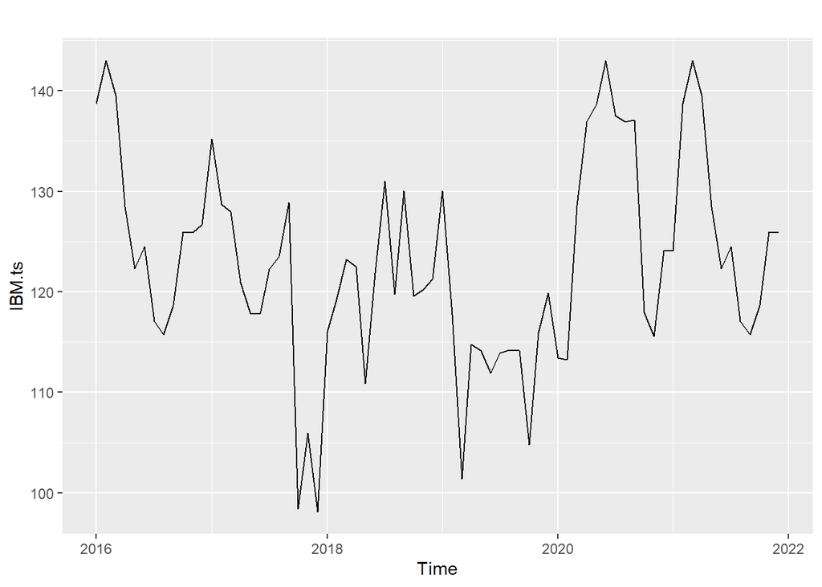

```r
IBM.ts <- ts(IBM$`Adj Close`
             , start = c(2016,01)
             , end = c(2021,12)
             , frequency = 12)

autoplot(IBM.ts)
```

## Traingin Testing split

```r
# training sets
train = window(IBM.ts, end = c(2021,5))
# testing sets
test = window(IBM.ts, start = c(2021,6)) # 7 months test set
```

## naïve Model

```r
naive.fit = naive(train)
naive.forecast = forecast(naive.fit, h = 7)
summary(naive.fit)
```

```
##
## Forecast method: Naive method
##
## Model Information:
## Call: naive(y = train)
##
## Residual sd: 8.6038
##
## Error measures:
##                      ME     RMSE      MAE       MPE     MAPE      MASE
## Training set -0.1610303 8.603805 6.367279 -0.391262 5.348099 0.5117722
##                    ACF1
## Training set -0.1620865
##
## Forecasts:
##          Point Forecast     Lo 80    Hi 80     Lo 95    Hi 95
## Jun 2021       128.4471 117.42088 139.4733 111.58395 145.3102
## Jul 2021       128.4471 112.85367 144.0405 104.59901 152.2952
## Aug 2021       128.4471 109.34913 147.5451  99.23927 157.6549
## Sep 2021       128.4471 106.39466 150.4995  94.72080 162.1734
## Oct 2021       128.4471 103.79172 153.1025  90.73995 166.1542
## Nov 2021       128.4471 101.43849 155.4557  87.14099 169.7532
## Dec 2021       128.4471  99.27446 157.6197  83.83140 173.0628
## Jan 2022       128.4471  97.26024 159.6340  80.75091 176.1433
## Feb 2022       128.4471  95.36844 161.5258  77.85765 179.0365
## Mar 2022       128.4471  93.57913 163.3151  75.12114 181.7731
```

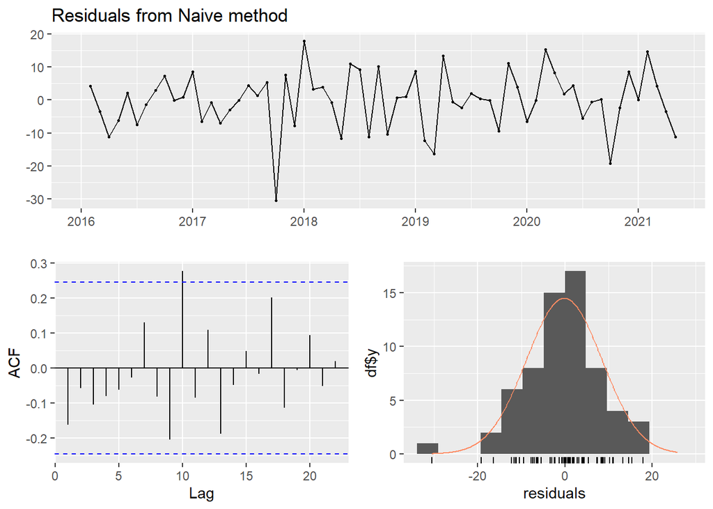

```
##
##  Ljung-Box test
##
## data:  Residuals from Naive method
## Q* = 18.881, df = 13, p-value = 0.1268
##
## Model df: 0.   Total lags used: 13
```

```r
checkresiduals(naive.forecast)
```

```r
accuracy(naive.forecast, test)
```

```
##                      ME     RMSE      MAE       MPE     MAPE      MASE
## Training set -0.1610303 8.603805 6.367279 -0.391262 5.348099 0.5117722
## Test set     -7.0044646 8.048907 7.004465 -5.881324 5.881324 0.5629862
##                    ACF1 Theil's U
## Training set -0.1620865        NA
## Test set      0.3440768  1.860543
```

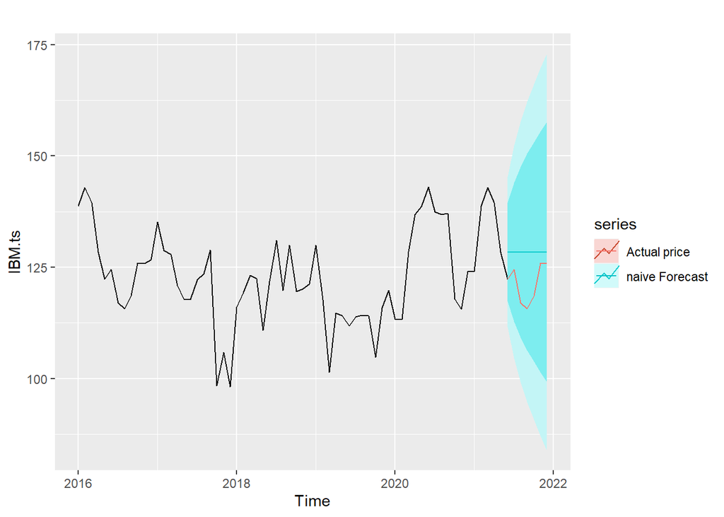

```r
autoplot(IBM.ts) +
  autolayer(naive.forecast, series = "naive Forecast") +
  autolayer(test , series = "Actual price")
```

## Seasonal naïve Model

Now I generated a Seasonal naive model and I checked the performance for the model forecasting on the test set. The Seasonal naive model generated a MASE = 1.009509 and a RMSE = 14.93724. the Seasonal naive model has worst RMSE and MASE than the naive model in this data, we will compare these models to check how good the next models are.

```r
snaive.fit = snaive(train)
snaive.forecast = forecast(snaive.fit, h = 7)
summary(snaive.fit)
```

```
##
## Forecast method: Seasonal naive method
##
## Model Information:
## Call: snaive(y = train)
##
## Residual sd: 15.1047
##
## Error measures:
##                    ME     RMSE      MAE        MPE     MAPE MASE      ACF1
## Training set 1.120724 15.10465 12.44163 0.06501426 10.26335    1 0.6949944
##
## Forecasts:
##          Point Forecast     Lo 80    Hi 80     Lo 95    Hi 95
## Jun 2021       143.0132 123.65576 162.3705 113.40858 172.6177
## Jul 2021       137.5205 118.16315 156.8779 107.91596 167.1251
## Aug 2021       136.9156 117.55826 156.2730 107.31107 166.5202
## Sep 2021       137.1005 117.74310 156.4579 107.49592 166.7051
## Oct 2021       117.9175  98.56007 137.2749  88.31289 147.5220
## Nov 2021       115.5580  96.20058 134.9154  85.95340 145.1626
## Dec 2021       124.0900 104.73260 143.4474  94.48542 153.6946
## Jan 2022       124.0900 104.73260 143.4474  94.48542 153.6946
## Feb 2022       138.7530 119.39564 158.1104 109.14846 168.3576
## Mar 2022       142.9669 123.60948 162.3243 113.36230 172.5714
## Apr 2022       139.5456 120.18825 158.9030 109.94106 169.1502
## May 2022       128.4471 109.08971 147.8045  98.84252 158.0517
## Jun 2022       143.0132 115.63767 170.3886 101.14596 184.8803
## Jul 2022       137.5205 110.14505 164.8960  95.65335 179.3877
## Aug 2022       136.9156 109.54016 164.2911  95.04846 178.7828
## Sep 2022       137.1005 109.72501 164.4760  95.23330 178.9677
## Oct 2022       117.9175  90.54198 145.2930  76.05027 159.7847
## Nov 2022       115.5580  88.18249 142.9335  73.69078 157.4252
## Dec 2022       124.0900  96.71451 151.4655  82.22280 165.9572
## Jan 2023       124.0900  96.71451 151.4655  82.22280 165.9572
## Feb 2023       138.7530 111.37755 166.1285  96.88584 180.6202
## Mar 2023       142.9669 115.59139 170.3424 101.09968 184.8341
## Apr 2023       139.5456 112.17015 166.9211  97.67845 181.4128
## May 2023       128.4471 101.07161 155.8226  86.57991 170.3143
```

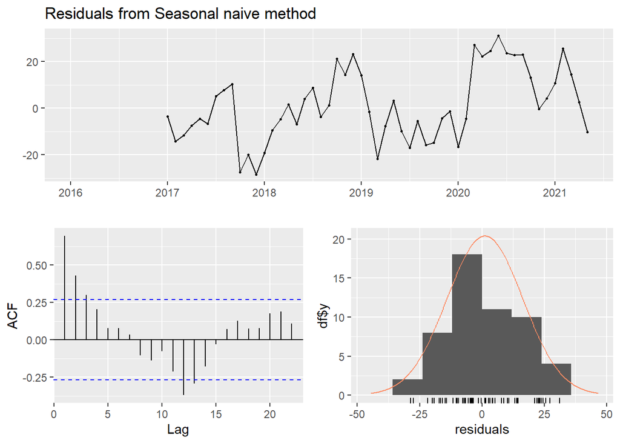

```
##
##  Ljung-Box test
##
## data:  Residuals from Seasonal naive method
## Q* = 67.748, df = 13, p-value = 2.08e-09
##
## Model df: 0.   Total lags used: 13
```

```r
checkresiduals(snaive.forecast)
```

```r
accuracy(snaive.forecast, test)
```

```
##                     ME     RMSE      MAE         MPE     MAPE     MASE
## Training set  1.120724 15.10465 12.44163  0.06501426 10.26335 1.000000
## Test set     -8.859548 14.93724 12.55994 -7.50162704 10.44927 1.009509
##                   ACF1 Theil's U
## Training set 0.6949944        NA
## Test set     0.4975722  3.040441
```

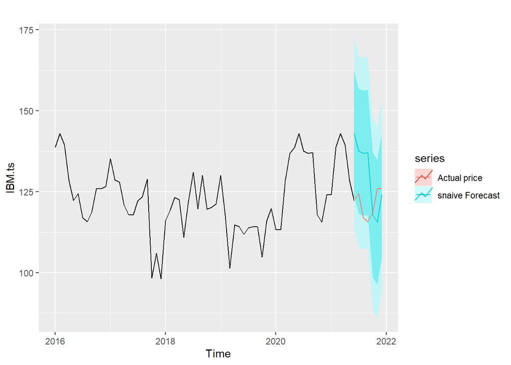

```r
autoplot(IBM.ts) +
  autolayer(snaive.forecast, series = "snaive Forecast") +
  autolayer(test , series = "Actual price" )
```

## ETS Model

In the subsequent model iteration, I generated a Error, Trend, Seasonal model and I checked the performance for the model forecasting on the test set. The ETS Model generated a MASE = 0.7658349 and a RMSE = 10.320349. Although the Seasonal naive model looks much better in the graph but the ETS model has better MASE and RMSE than the Seasonal naive model.

```r
ETS.fit = ets(train)
ETS.forecast = forecast(ETS.fit, h = 7)
summary(ETS.fit)
```

```
## ETS(A,N,N)
##
## Call:
##  ets(y = train)
##
##   Smoothing parameters:
##     alpha = 0.7803
##
##   Initial states:
##     l = 139.3797
##
##   sigma:  8.5227
##
##      AIC     AICc      BIC
## 553.8585 554.2520 560.3817
##
## Training set error measures:
##                      ME     RMSE      MAE        MPE     MAPE      MASE
## Training set -0.1657896 8.390522 6.360628 -0.4314712 5.313923 0.5112376
##                    ACF1
## Training set 0.02617773
```

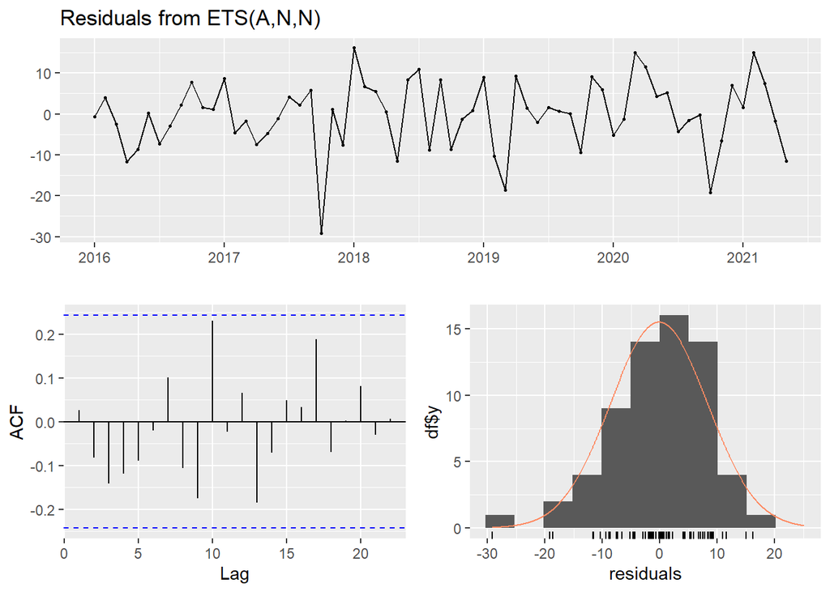

```
##
##  Ljung-Box test
##
## data:  Residuals from ETS(A,N,N)
## Q* = 15.063, df = 11, p-value = 0.1796
##
## Model df: 2.   Total lags used: 13
```

```r
checkresiduals(ETS.forecast)
```

```r
accuracy(ETS.forecast, test)
```

```
##                      ME      RMSE      MAE        MPE     MAPE      MASE
## Training set -0.1657896  8.390522 6.360628 -0.4314712 5.313923 0.5112376
## Test set     -9.5282328 10.320349 9.528233 -7.9617128 7.961713 0.7658349
##                    ACF1 Theil's U
## Training set 0.02617773        NA
## Test set     0.34407683  2.358706
```

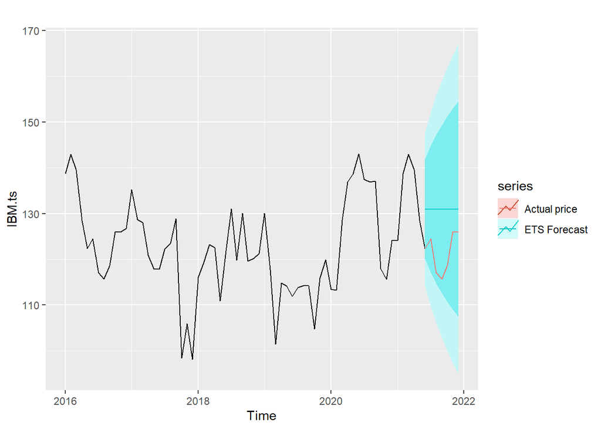

```r
autoplot(IBM.ts) +
  autolayer(ETS.forecast, series = "ETS Forecast") +
  autolayer(test , series = "Actual price")
```

## ARIMA Model

Next I implemented, an ARIMA Model and I checked the performance for the model, and the model returned a MASE = 0.3730515 and a RMSE = 5.452839 , the ARIMA Model is better than the ETS model for this data.

```r
ARIMA.fit = auto.arima(train)
ARIMA.forecast = forecast(ARIMA.fit, h = 7)
summary(ARIMA.fit)
```

```
## Series: train
## ARIMA(1,0,0) with non-zero mean
##
## Coefficients:
##          ar1      mean
##       0.6766  123.6739
## s.e.  0.0914    2.9404
##
## sigma^2 estimated as 64.08:  log likelihood=-226.73
## AIC=459.45   AICc=459.84   BIC=465.97
##
## Training set error measures:
##                      ME     RMSE      MAE        MPE     MAPE     MASE
## Training set -0.2187022 7.880822 6.030221 -0.6106283 5.036667 0.484681
##                     ACF1
## Training set 0.004000209
```

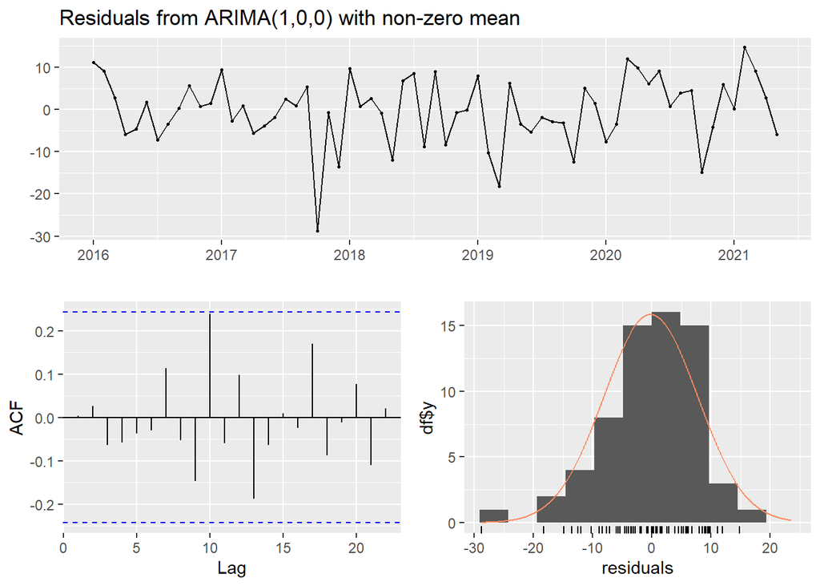

```
##
##  Ljung-Box test
##
## data:  Residuals from ARIMA(1,0,0) with non-zero mean
## Q* = 12.161, df = 11, p-value = 0.3516
##
## Model df: 2.   Total lags used: 13
```

```r
checkresiduals(ARIMA.forecast)
```

```r
accuracy(ARIMA.forecast, test)
```

```
##                      ME     RMSE      MAE        MPE     MAPE      MASE
## Training set -0.2187022 7.880822 6.030221 -0.6106283 5.036667 0.4846810
## Test set     -3.5651856 5.452839 4.641368 -3.0470940 3.901612 0.3730515
##                     ACF1 Theil's U
## Training set 0.004000209        NA
## Test set     0.350809618  1.245145
```

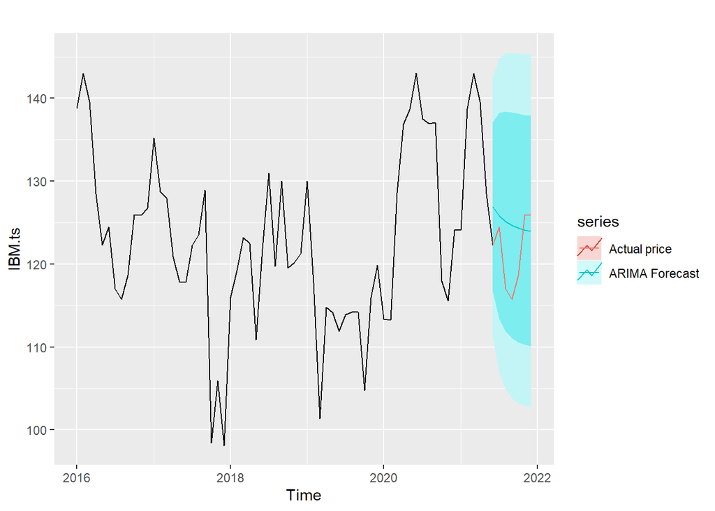

```r
autoplot(IBM.ts) +
  autolayer(ARIMA.forecast, series = "ARIMA Forecast") +
  autolayer(test , series = "Actual price")
```

## Neural Network Model

```
## For a multivariate time series, specify a seriesname for each time series. Defaulting to column names.
```

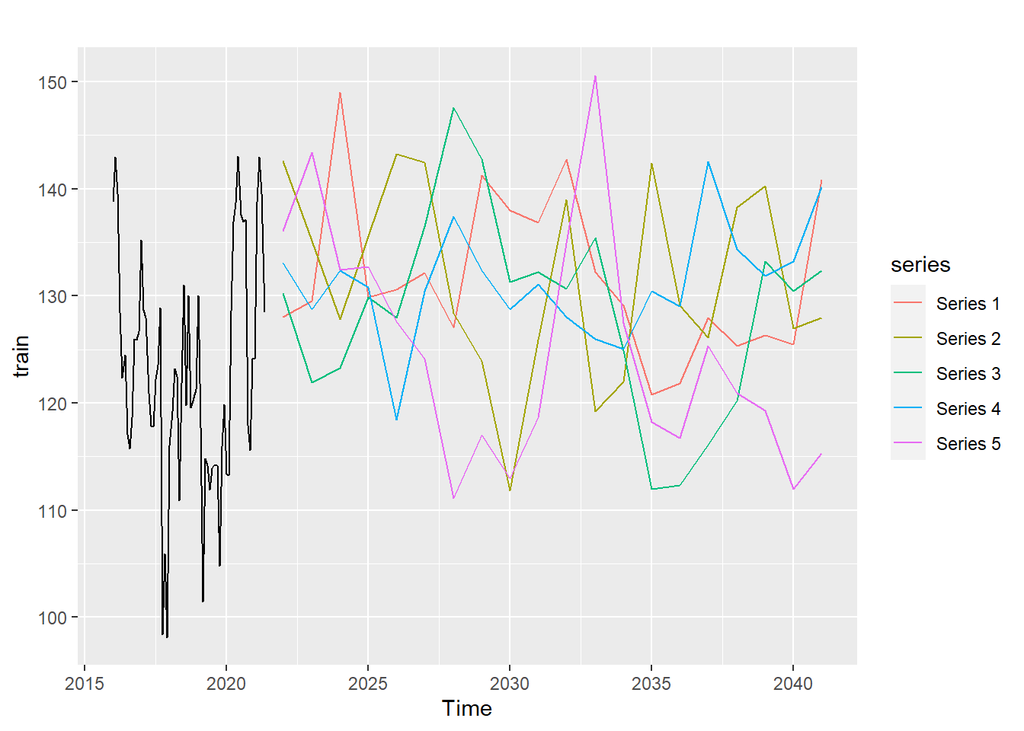

```r
library(forecast)
nn.fit = nnetar(train, lambda=0)


sim <- ts(matrix(0, nrow=20, ncol=5), start=end(train)[1]+1)
for(i in seq(5))
  sim[,i] <- simulate(nn.fit, nsim=20)
library(ggplot2)
ggplot2::autoplot(train) + forecast::autolayer(sim)
```

```r
nn.forecast <- forecast(nn.fit, PI=TRUE, h=7)
```

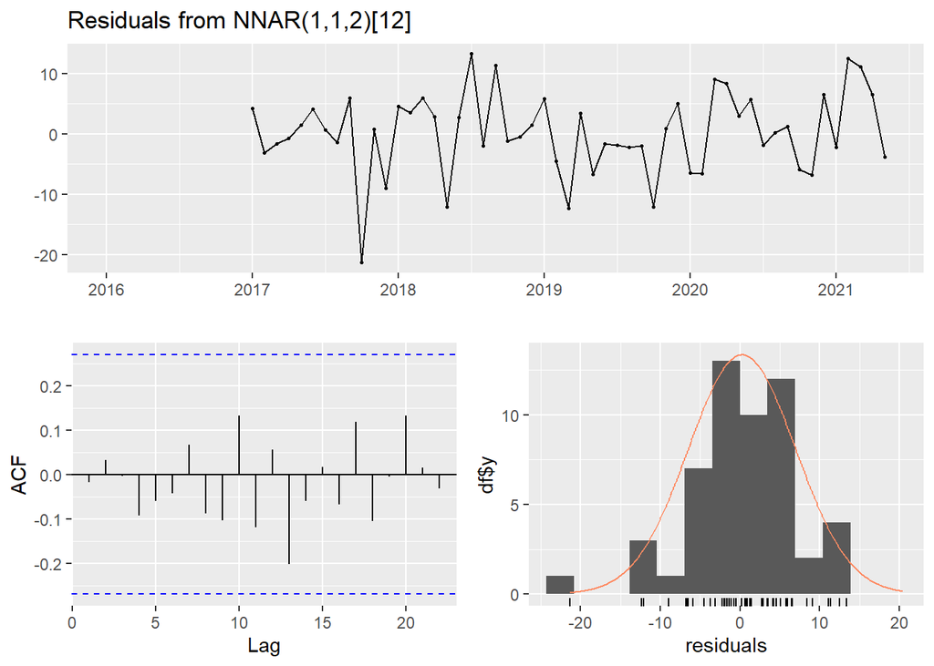

```r
checkresiduals(nn.forecast)
```

```r
accuracy(nn.forecast, test)
```

```
##                      ME     RMSE      MAE        MPE     MAPE      MASE
## Training set  0.2435195 6.680952 5.135147 -0.1672064 4.310410 0.4127391
## Test set     -5.7082220 8.249563 6.921818 -4.8453356 5.809218 0.5563434
##                     ACF1 Theil's U
## Training set -0.01775234        NA
## Test set      0.43566125  1.848878
```

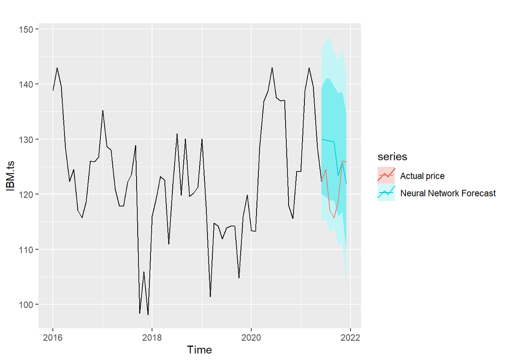

```r
autoplot(IBM.ts) +
  autolayer(nn.forecast, series = "Neural Network Forecast") +
  autolayer(test , series = "Actual price")
```

## Conclusion

```r
data.frame(Model = c("1.naive modlel", "2.snaive model", "3.ETS model", "4.ARIMA model", "5.Neural Network"), "RMSE" = c(8.048907,14.93724 ,10.320349,5.452839,9.559687), "MASE" = c(0.5629862,1.009509,0.7658349,0.3730515,0.6892889))
```

[output not shown]

[output not shown]

5 rows

Ultimately, the ARIMA model returned the best results (MASE = 0.3730515 and RMSE = 5.452839), when we compare it to the actual test data, So we can choose the ARIMA model among these models to forecast the future IBM adjusted stock price.